# Amsterdam city swim

The open water swimming event through the canals of Amsterdam.

## Tour Boats

This assignment seeks to reduce air pollution from canal boats and support boats. As a result, the health and safety of event participants should be prioritized.

1. How many of the canal boats currently in use are diesel/fossil fuel-driven and how many boats are electric?

In 2024: Based on a canal fleet of 310 canal boats, at least 90% of canal boats will be electric (around 280 boats), and 10% will still be diesel-driven (around 30 boats). The Amsterdam canal cruise fleet contained 310 boats in 2016. While this number is highly likely to have changed in seven years, we use it for the purpose of calculations. In 2020, 75% of the registered commercial vessels in Amsterdam were already electric (Source: [Reuters](https://www.reuters.com/article/us-climate-change-netherlands-idUSKBN20Q1W7)), which includes canal boats. The city is aiming for all commercial and residential boats to be emissions-free by 2025 (Source: [Electrisch varen- Gemeente Amsterdam](https://www.amsterdam.nl/verkeer-vervoer/varen-amsterdam/elektrisch-varen/)). Because the swim takes place in 2024, additional boats must be electrified to reach the 2025 goal. By linear regression, we assume that at least 90% of the Amsterdam canal cruise fleet will be electric by mid-2024.

2. Are there peak times for the canal boats?

The canals have variable traffic times, which are represented in Figure 2 in Assignment 1. For our hand-selected route and event timing, we selected canals with minimal traffic and optimized for the early morning to avoid commercial boats. Additionally to that information, we found in a municipality document ‘Grachtenmonitor 2022’ more information about peak times for the canal boats.

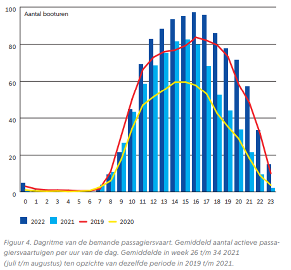

Figure 4 shows a clear peak in canalboat activity on the water. In the afternoon at 4 p.m. (source: [Grachtenmonitor 2022 - openresearch.amsterdam](https://openresearch.amsterdam/nl/page/92981/grachtenmonitor-2022)).

3. Do canal boats use more or less energy in relation to their carbon footprint compared to other activities in the city?

To power a cruise fleet of 310 boats, the amount of energy needed per year is 9000 MWh. This is equivalent to 2.3 million liters of diesel (TNO 2016 Electrische rondvaart in Amsterdam). Of course, when the energy is generated in a sustainable way, the carbon footprint declines. We found that electric buses consume 75.000 kWh per year with an average drive of 75.000 km (source: [Waterstofgate.nl - Businesscase Bussen (CO2 uitstoot)](https://waterstofgate.nl/Praktijk/Businesscase-Bussen-verbruik/Businesscase-Bussen-CO2-uitstoot/#:~:text=Een%20bus%20rijdt%2075.000%20km,per%20jaar%20487.500.000%20kWh).). 9000 MWh= 9.000.000 kWh. 9.000.000/75.000 = 120. So, with this energy 120 buses can serve the city as well.

4. Would you consider it economically feasible?

(TNO) calculated a business case about the costs of electrifying a canal cruise boat. Taking into account the fuel and energy price at that time and the financial losses due to the time that the boat is not in operation, it is estimated that the payback period in 2016 was 12 years. For 2024, it is estimated to be 6 years. We think it is feasible to make the transition and electrify the cruise boats.

5. How many support boats and vehicles are needed for the Paralympics event?

100 support boats (escort boats) will be needed for the event. This is based on a decision to include 100 swimmers. Number of vessels. We plan to designate this race as an escorted swim based on the variable conditions and safety requirements for each athlete. According to ([FINA](https://resources.fina.org/fina/document/2021/02/03/84a6f630-7803-4915-8b27-a95e986cefc1/fina_ow_manual_2020_14may2020.pdf)) (now World Aquatics) and ( [USMS](https://www-usms-hhgdctfafngha6hr.z01.azurefd.net/-/media/usms/pdfs/volunteer%20central/rule%20book/part%203.pdf?rev=6e38286c5146418199effc76c3086400&hash=4CE3D46C10E9E14F0004853C48943B93)) (U.S. Masters Swimming) regulations for open water swim events, escorted races require each swimmer to have a designated support vessel. Number of swimmers. To ensure ample room for escort boats, swimmers, and other canal users, we will limit the race to 100 total swimmers. To appropriately estimate of the number of participants, we were able to find ([one dataset](https://nocnsf.nl/media/5838/if-eisenps-parijs-2024-para-zwemmen.pdf)) for the Paris 2024 games listing a total of 605 swimmers across all short-distance events (those under 200 meters). We originally began with this number of swimmers. However, since the Amsterdam event is a longer-distance swim with limited open water, we made the decision to limit the number of swimmers to 50 men and 50 women based on current gender splits for official races.

6. If only clean energy can be used, how many solar panels are needed?

Though not all support boats will be motorized in reality (some will be rowed manually), we assume that all 100 boats will be motorized. By making this assumption, we can calculate a gasoline requirement.

• According to ([boating rules](https://www.iamsterdam.com/en/travel-stay/getting-around/boating)), the maximum speed for boats in Amsterdam is 6 km/h.

• Boats must comply with the most ([recent regulations](https://www.nmma.org/assets/cabinets/Cabinet450/CCGuideDirective2003-44.pdf)) for two-stroke engines. To achieve a maximum speed of 6km/h, a two-stroke engine requires 2.5 hp – up to 4.55 L/h of diesel at top speed.

• For 4 hours of operation, each boat will require 18.2 liters of fuel. For a 100-boat fleet, the total energy requirement would be 1820 liters of fuel for the event.

To calculate the solar requirement, we would have preferred to calculate the kWh requirement based on the requisite liters of fuel. We tried several routes, but it becomes complex based on the engine type and speed.

For the sake of the exercise, we used data from ([VEEL GESTELDE VRAGEN - Ampera Boats](https://www.amperaboats.com/veelgestelde-vragen/#:~:text=Het%20energieverbruik%20van%20een%20boot,de%20ideale%20snelheid%20te%20vinden).) which notes that energy consumption for a 6-meter boat traveling at 6 km/h is 0,8 kWh for 1 hour. Most escort vessels will likely be smaller, but this provides an ample number for safety and planning purposes.

• For 100 boats over 4 hours, the energy requirement is 320 kWh.

• Amsterdam receives an average of 7.41 sun-hours in May. Multiplied by a solar derating factor of 0.8, this effectively leaves 6 sun-hours for solar operation.

• 320 kWh / 6 sun-hours = an estimated power requirement of 54 kW for one day of full charging.

8. Would there be any effect on the water quality if there are less/no canal boats using fossil fuels?

Electrifying boats reduce particulate matter (PM) emissions during the event as well as lifetime emissions of the boats in general (source: [ICCT](https://theicct.org/publication/marine-ports-electrification-feb23/)). Burning fossil fuels impacts not only the air quality but the water quality as well – PM can settle on water and potentially increase acidity and turbidity of the water (source: [EPA.gov](https://www.epa.gov/pm-pollution/health-and-environmental-effects-particulate-matter-pm))

To home page